# Lab

## Classfication Trees

```r
library(tree)
library(tidyverse)
library(ISLR)
library(rlang)
carseats <-  Carseats
carseats$High <- factor(ifelse(carseats$Sales <=8,"No","Yes"))
```

For trees, deviance is

$$-2\sum_m\sum_kn_{mk}\log\hat{p}_{mk}$$

Smaller is better. Residual mean deviance is deviance divided by $n - |T_0|$

```r
carseats_tree <- tree(formula = High~. -Sales, data = carseats)

summary(carseats_tree)
```

```
##
## Classification tree:
## tree(formula = High ~ . - Sales, data = carseats)
## Variables actually used in tree construction:
## [1] "ShelveLoc"   "Price"       "Income"      "CompPrice"   "Population"
## [6] "Advertising" "Age"         "US"
## Number of terminal nodes:  27
## Residual mean deviance:  0.4575 = 170.7 / 373
## Misclassification error rate: 0.09 = 36 / 400
```

Trees are easy to plot, thankfully.

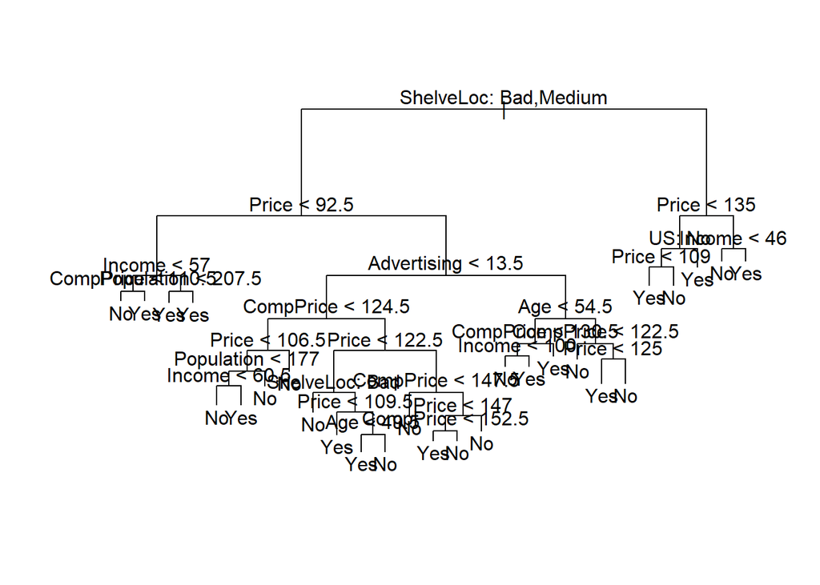

```r
plot(carseats_tree)
text(carseats_tree, pretty=0)
```

What is test error?

```r
set.seed(2)
inds <- sample(1:nrow(carseats), 200)
train <- carseats[inds,]
test <- carseats[-inds,]
actual <- carseats$High[-inds]

tree_carseats <- tree(High~.-Sales, carseats, subset = inds)
preds <- predict(tree_carseats, test, type = "class" )

table(preds, actual)
```

```
##      actual
## preds  No Yes
##   No  104  33
##   Yes  13  50
```

```r
table(preds, actual) %>% {sum(diag(.))}/200
```

```
## [1] 0.77
```

We should prune the tree to check if fit improves. Set FUN=prune.misclass to use classification error as the criterion (default deviance). The function reports size and error rate of each tree, as well as $k$ (or $\alpha$), the complexity penalty.

```r
set.seed(3)
cv_carseats <- cv.tree(tree_carseats, FUN = prune.misclass)
cv_carseats
```

```
## $size
## [1] 21 19 14  9  8  5  3  2  1
##
## $dev
## [1] 74 76 81 81 75 77 78 85 81
##
## $k
## [1] -Inf  0.0  1.0  1.4  2.0  3.0  4.0  9.0 18.0
##
## $method
## [1] "misclass"
##
## attr(,"class")
## [1] "prune"         "tree.sequence"
```

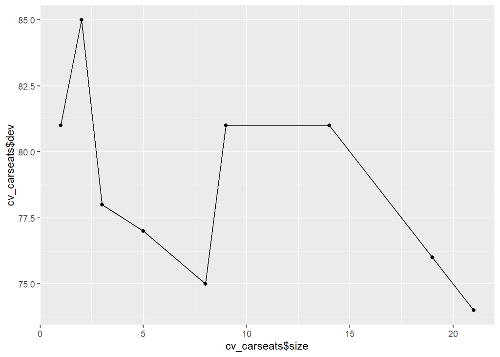

```r
tibble(cv_carseats$size, cv_carseats$dev) %>%
  ggplot(aes(x = cv_carseats$size, y = cv_carseats$dev)) +
  geom_point()+
  geom_line()
```

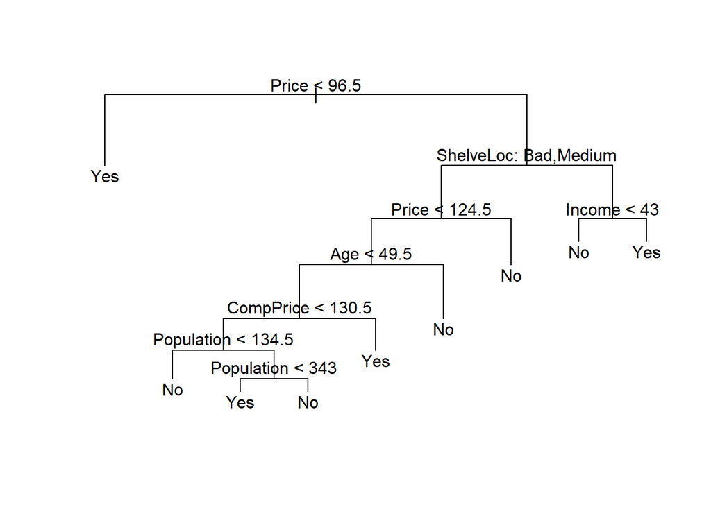

```r
carseats_pruned <- prune.misclass(tree_carseats, best = 9)
plot(carseats_pruned)
text(carseats_pruned, pretty = 0)
```

```r
pruned_pred <- predict(carseats_pruned, test, type = "class")
table(pruned_pred, actual)
```

```
##            actual
## pruned_pred No Yes
##         No  97  25
##         Yes 20  58
```

```r
table(pruned_pred, actual) %>% {sum(diag(.))/sum(.)}
```

```
## [1] 0.775
```

A higher number of nodes in this case results in a bigger tree with worse test error.

## Regression Trees

Not much to see here. Deviance for regression is just SSE.

```r
Boston <- MASS::Boston

set.seed(1)
train <-  sample(1:nrow(Boston), nrow(Boston)/2)

tree.boston <- tree(medv∼. , data = Boston , subset=train)

summary(tree.boston)
```

```
##
## Regression tree:
## tree(formula = medv ~ ., data = Boston, subset = train)
## Variables actually used in tree construction:
## [1] "rm"    "lstat" "crim"  "age"
## Number of terminal nodes:  7
## Residual mean deviance:  10.38 = 2555 / 246
## Distribution of residuals:
##     Min.  1st Qu.   Median     Mean  3rd Qu.     Max.
## -10.1800  -1.7770  -0.1775   0.0000   1.9230  16.5800
```

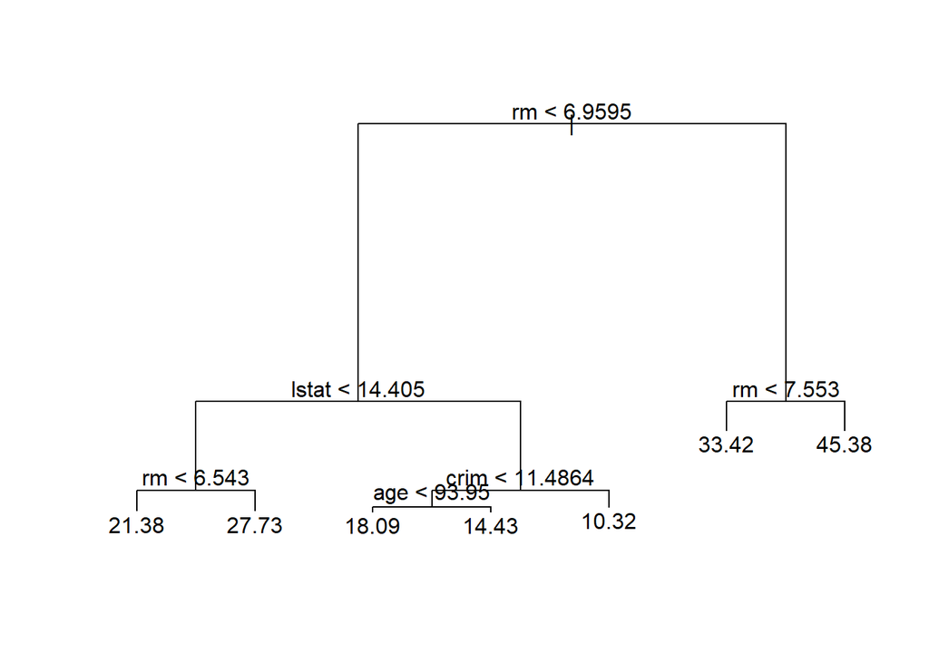

```r
plot(tree.boston)
text(tree.boston, pretty = 0)
```

Looks like the more complex tree is best here.

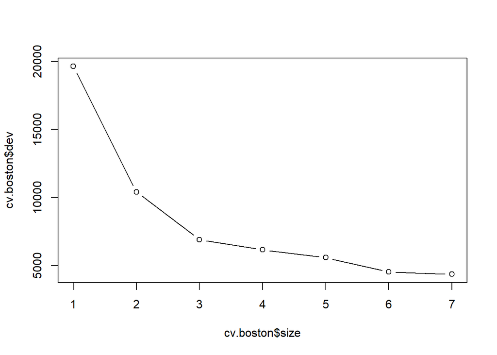

```r
cv.boston <- cv.tree(tree.boston)
plot(cv.boston$size, cv.boston$dev, type = "b")
```

RMSE not so bad.

```r
test <- Boston[-train,]
actual <- test$medv
boston_pred <- predict(tree.boston, newdata = test)
sqrt(mean((boston_pred-actual)^2))
```

```
## [1] 5.940276
```

## Bagging

Mtry is variables to use for each split - since we use all 13, this is bagging rather than a true random forest.

```r
library(randomForest)
set.seed(1)
train <- sample(nrow(Boston), nrow(Boston) / 2)
test <- Boston[-train,]

bos_bag <- randomForest(medv ~ ., data = Boston, subset = train, mtry = 13, importance = TRUE)

bos_bag
```

```
##
## Call:
##  randomForest(formula = medv ~ ., data = Boston, mtry = 13, importance = TRUE,      subset = train)
##                Type of random forest: regression
##                      Number of trees: 500
## No. of variables tried at each split: 13
##
##           Mean of squared residuals: 11.33119
##                     % Var explained: 85.26
```

The model did well, but badly undershot high values.

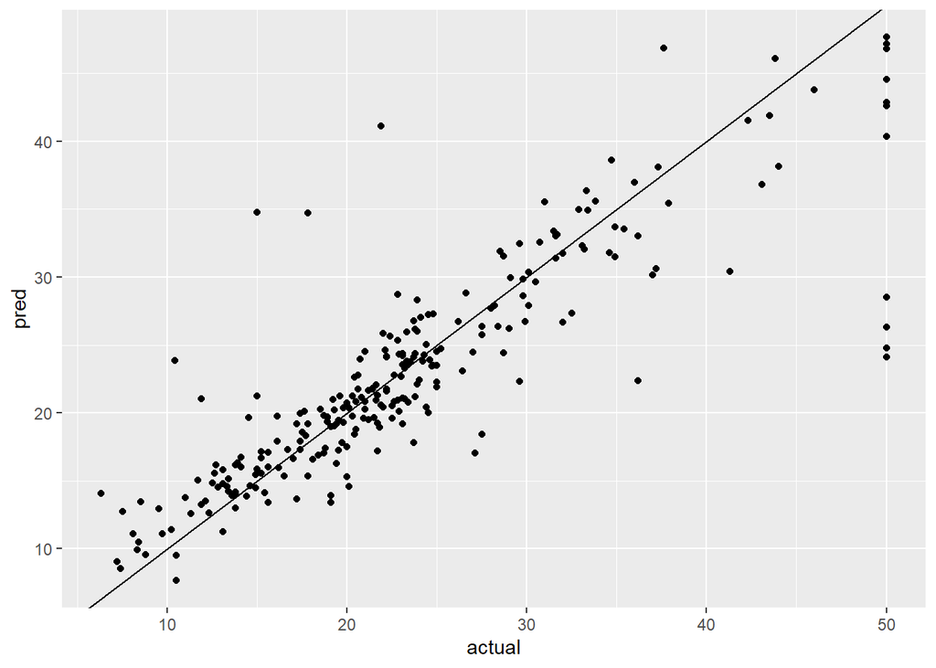

```r
bag_pred <- predict(bos_bag, newdata = test)
tibble(actual = test$medv, pred = bag_pred) %>%
  ggplot(aes(x = actual, y = pred)) +
  geom_point() +
  geom_abline()
```

MSE is higher than the ISLR authors report, for some reason.

```r
mean((bag_pred - test$medv)^2)
```

```
## [1] 23.4579
```

```r
bos_bag2 <- randomForest(medv ~., data = Boston, subset = train, mtry = 13, ntree = 25, importance = TRUE)
```

Random forests just use different values of mtry. By default, randomForest uses $p/3$ for regression and $/sqrtp$ for classification.

We improve substantially over bagging.

```r
rf_boston <- randomForest(medv ~., data = Boston, subset = train, mtry = 6, importance = TRUE)

pred <- predict(rf_boston, newdata = test)
mean((pred-test$medv)^2)
```

```
## [1] 20.00797
```

Importance of predictors. The first column is mean accuracy decrease for omitting that predictor, the second the total decrease in node impurity (for regression, train RSS; for classification, deviance) achieved by splitting on that variable

```r
importance(rf_boston)
```

```
##            %IncMSE IncNodePurity
## crim    16.1381519    1140.21415
## zn       2.7696849     102.91403
## indus    4.7490593     617.55665
## chas     0.3517492      32.30192
## nox     13.8124457     797.75371
## rm      32.9365080    7835.47937
## age     14.6347276     608.19425
## dis     10.5930253     722.53436
## rad      3.7552572      86.27498
## tax      8.3251262     281.60182
## ptratio  8.2531350     786.30693
## black    8.1647041     271.35076
## lstat   28.4300498    5857.78317
```

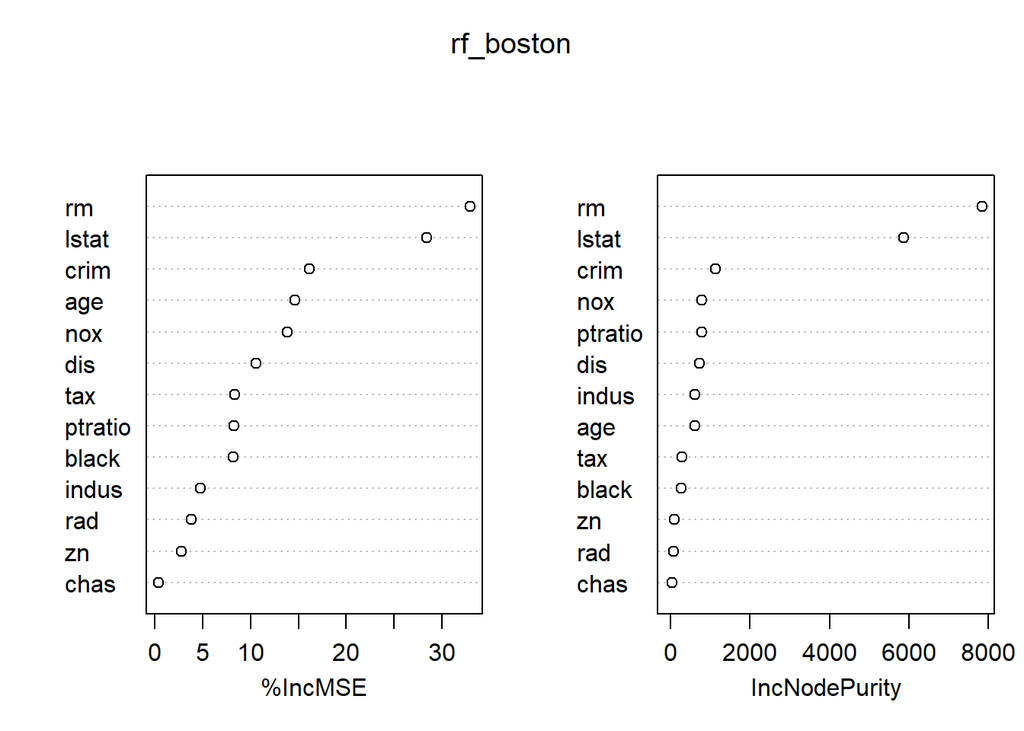

```r
varImpPlot(rf_boston)
```

Note distribution type - would be Bernoulli for classification.

## Boosting

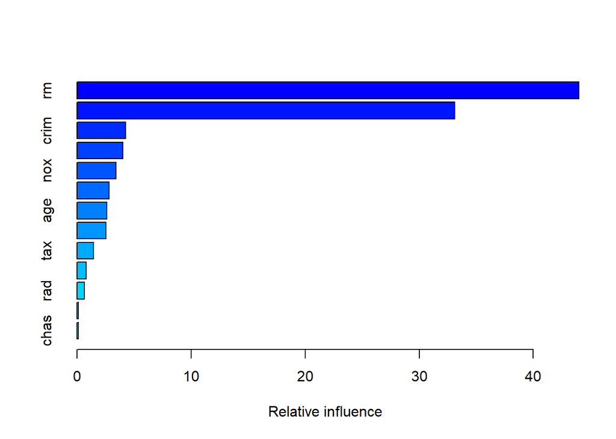

```
##             var    rel.inf
## rm           rm 43.9919329
## lstat     lstat 33.1216941
## crim       crim  4.2604167
## dis         dis  4.0111090
## nox         nox  3.4353017
## black     black  2.8267554
## age         age  2.6113938
## ptratio ptratio  2.5403035
## tax         tax  1.4565654
## indus     indus  0.8008740
## rad         rad  0.6546400
## zn           zn  0.1446149
## chas       chas  0.1443986
```

```r
library(gbm)
set.seed(1)
bos_boost <- gbm(medv ~ ., data = Boston[train,], distribution = "gaussian", n.trees = 5000, interaction.depth = 4)
summary(bos_boost)
```

These are partial dependence plots for two variables - they show the impact on the response holding all others constant.

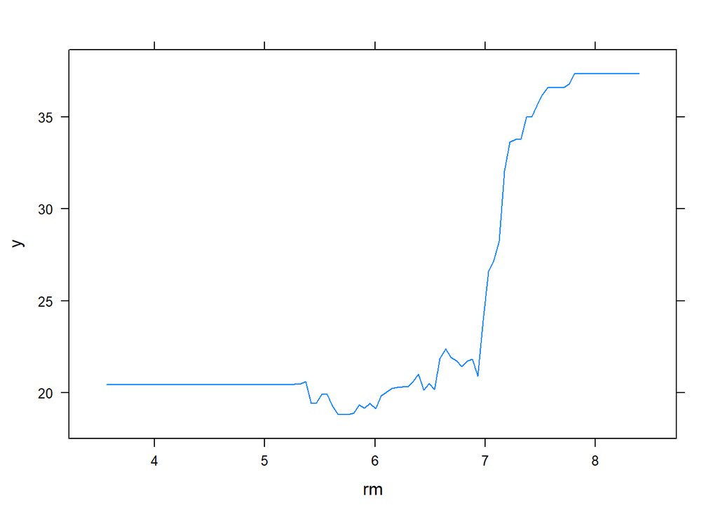

```r
par(mfrow = c(1,2))
plot(bos_boost, i = "rm")
```

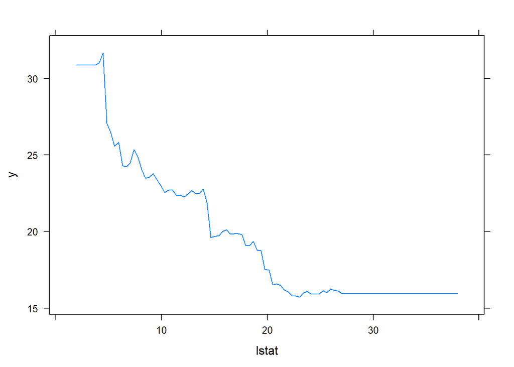

```r
plot(bos_boost, i = "lstat")
```

Use shrinkage arg to set $\lambda$ (shrinkage on backfitted trees).

```r
boost.boston <- gbm(medv∼., data=Boston[train,], distribution="gaussian", n.trees=5000, interaction.depth=4, shrinkage=0.2, verbose=F)
```

# Conceptual Problems

## 2.

We are reminded boosting with stumps creates an additive model:

$$f(X)=\sum_{j=1}^pf_j(X_j)$$

that is, the sum of a separate function applied to each predictor. This occurs because each stump must use only one predictor. So the final model consists of the sum of sums of shrunken stumps fitted one each predictor. Say each predictor gets k splits:

$$f(x) = \sum_{j=1}^p\sum_{k=1}^k\lambda{f_k(X_j)}$$

## 5

We have 10 bootstrapped sample probabilities for $P(Red|X)$, where there are two classes:

```r
probs <- c(.1,.15,.2,.2,.55,.6,.6,.65,.7,.75)

maj <- ifelse(sum(probs >.5), "red", "green")
avg <- ifelse(mean(probs) > .5, "red", "green")
```

Classifications are different. We see using majority vote ignores the model’s confidence in the classification (the probability).

## 4.

Explain the regression tree algorithm.

First, a number of $J$ regions (giving $J-1$ splits) is selected. For the initial split, every possible split over each predictor is considered; the one chosen minimizes the combined SSE (the sum of the two regions’ sum of sqaured deviations of each region’s response values’ deviations from that region’s mean [or some other fit method]). Then we consider possible splits of the two regions, and perform the best by the same criterion. This repeats, considering all $n+1$regions of iteration $n$, until an exhaustion criterion (usually number of observations in each terminal node) is reached. Critically, *only one split is ever made at each step* - this saves resources but rules out splits that yield poor initial SSE improvement but would result in better trees following additional splits.

## 6

Try different mtry for Boston. More fun with quasiquotation.

```r
library(randomForest)
set.seed(1)
grid <- expand_grid(mtry = 1:11, ntree = seq(50, 500, by = 50))
boston <- MASS::Boston
train <- slice_sample(boston, n = nrow(boston)/2)
test <- anti_join(MASS::Boston, train)
```

```r
actual <- test$medv

# No more silliness
call <- quote(randomForest(data = train,  medv~.-chas-zn, importance = TRUE))

forests <- map2(grid$mtry, grid$ntree, ~eval(call_modify(call, !!!list(mtry = .x, ntree = .y)))) %>%
  set_names(reduce(grid, paste, sep = "-"))

preds <- map(forests, predict, newdata = test) %>%
  map_dbl( ~mean((.x-test$medv)^2))
```

Totally irrelevant to ISLR, but here’s a function I wrote that assigns a symbol bound to a symbol to a symbol bound to another symbol. R is amazing.

```r
# More stupid quasiquotation games
xzibit_assign <- function(expr, val){
  eval(bquote(.(substitute(expr)) <- .(val)))

}
```

It seems just a few variables led to the best MSE trees.

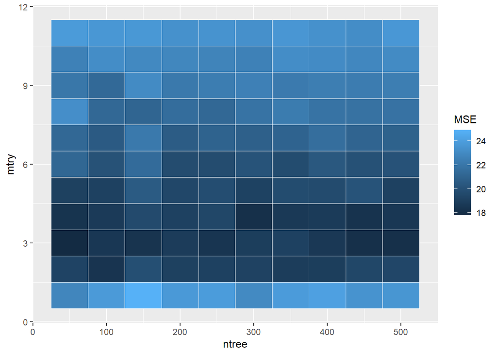

```r
preds %>% enframe(name = "temp", value = "MSE" ) %>%
  separate(temp, sep = "-", into = c("mtry", "ntree")) %>%
  mutate(across(everything(), as.numeric)) %>%
  ggplot(aes(x = ntree, y = mtry, fill = MSE)) +
  geom_tile(col = "white") +
  scale_fill_gradient()
```

##8.

This problem asks us to use classification on Carseats.

```r
carseats <- ISLR::Carseats
train <- slice_sample(carseats, n = nrow(carseats)/2)
test <- anti_join(carseats, train)
```

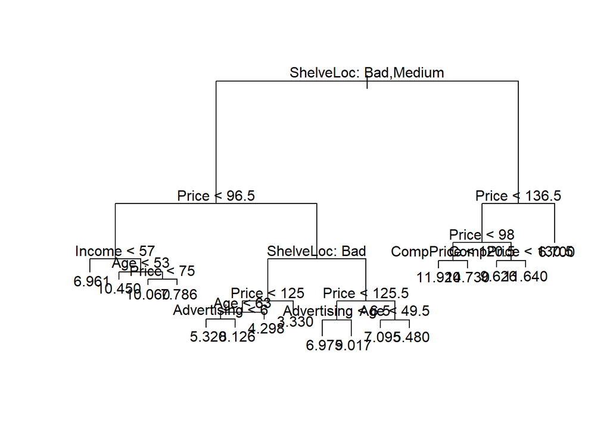

```r
carseats1 <- tree(Sales ~ ., data = train)
plot(carseats1)
text(carseats1, pretty = 0)
```

MSE is about 5, about a third the variable’s range. Not good.

```r
pred <- predict(carseats1, newdata = test)

mse <- function(pred, response){
  mean((pred-response)^2)
}

mse(pred, test$Sales)
```

```
## [1] 4.790067
```

```r
summary(carseats$Sales)
```

```
##    Min. 1st Qu.  Median    Mean 3rd Qu.    Max.
##   0.000   5.390   7.490   7.496   9.320  16.270
```

```r
alphas = 1:10
cv.tree(carseats1) %>%
  {tibble(size = .$size, dev = .$dev, k = .$k)}  %>%
  arrange(dev)
```

```
## # A tibble: 16 x 3
##     size   dev      k
##    <int> <dbl>  <dbl>
##  1    14  919.   22.4
##  2    13  919.   23.0
##  3    15  920.   20.7
##  4    16  926.   18.5
##  5    11  929.   23.9
##  6    10  929.   24.5
##  7    17  933. -Inf
##  8     9  953.   36.2
##  9     7 1021.   50.6
## 10     8 1023.   41.8
## 11     6 1066.   57.8
## 12     5 1066.   61.1
## 13     3 1246.  135.
## 14     2 1247.  177.
## 15     4 1265.  124.
## 16     1 1630.  391.
```

```r
carseats2 <- prune.tree(carseats1, best = 12)

mse(predict(carseats2, test), test$Sales)
```

```
## [1] 4.809402
```

A simple bagged model halves MSE! Removing weak predictors worsens MSE, however.

```r
library(randomForest)

carseats_bag <- randomForest(data = train, mtry = ncol(carseats)-1, Sales ~ ., ntree = 1000)
carseats_bag
```

```
##
## Call:
##  randomForest(formula = Sales ~ ., data = train, mtry = ncol(carseats) -      1, ntree = 1000)
##                Type of random forest: regression
##                      Number of trees: 1000
## No. of variables tried at each split: 10
##
##           Mean of squared residuals: 2.640756
##                     % Var explained: 67.19
```

```r
importance(carseats_bag)
```

```
##             IncNodePurity
## CompPrice      106.579788
## Income          70.389294
## Advertising    130.150464
## Population      52.359693
## Price          515.451225
## ShelveLoc      500.996592
## Age            141.162088
## Education       37.053515
## Urban            9.092722
## US              10.757647
```

```r
mse(predict(carseats_bag, test), test$Sales)
```

```
## [1] 2.84513
```

```r
carseats_bag2 <- randomForest(data = train, Sales ~ . - US - Urban, ntree = 1000)

mse(predict(carseats_bag2, test), test$Sales)
```

```
## [1] 3.441468
```

```r
carseats_rf <- randomForest(data = train, mtry = 8, Sales ~ ., ntree = 1000)

mse(predict(carseats_rf, test), test$Sales)
```

```
## [1] 2.897707
```

## 9.

We are now asked to predict purchases of orange juice, using pruning to refine the tree.

Brand loyalty is by far the most critical predictor.

```r
library(tree)
OJ <- ISLR::OJ

inds <- sample(nrow(OJ), 800)
train <- OJ[inds,]
test <- OJ[-inds,]

OJ_tree <- tree(data = train, Purchase ~.)
summary(OJ_tree)
```

```
##
## Classification tree:
## tree(formula = Purchase ~ ., data = train)
## Variables actually used in tree construction:
## [1] "LoyalCH"        "SalePriceMM"    "WeekofPurchase" "ListPriceDiff"
## Number of terminal nodes:  7
## Residual mean deviance:  0.7249 = 574.9 / 793
## Misclassification error rate: 0.1675 = 134 / 800
```

```r
mean(train$Purchase == "MM")
```

```
## [1] 0.39625
```

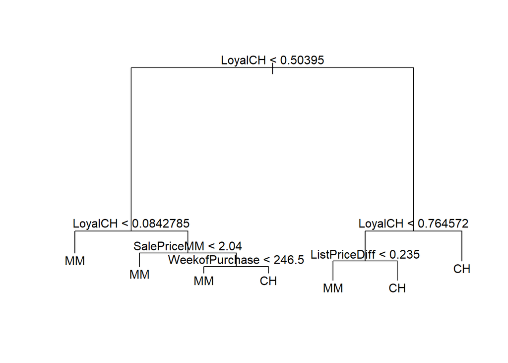

```r
plot(OJ_tree)
text(OJ_tree)
```

```r
OJ_pred <- predict(OJ_tree, test, mode = "response") %>% as.data.frame()
OJ_pred <- with(OJ_pred, factor(ifelse(CH > MM, "CH", "MM")))

table(OJ_pred, actual = test$Purchase) %>%
  {1-sum(diag(.))/sum(.)}
```

```
## [1] 0.2444444
```

5 or 6 nodes is best. I would plot the classification error if the function worked properly.

Training error is worst, as we’d expect.

```r
cv.tree(OJ_tree)
```

```
## $size
## [1] 7 6 5 4 3 2 1
##
## $dev
## [1]  676.4724  665.0415  666.2658  720.7154  721.4653  763.2218 1077.1593
##
## $k
## [1]      -Inf  12.79864  26.76301  37.87880  42.80803  58.80920 320.42950
##
## $method
## [1] "deviance"
##
## attr(,"class")
## [1] "prune"         "tree.sequence"
```

```r
pruned <- prune.tree(OJ_tree, best = 5)
summary(pruned)
```

```
##
## Classification tree:
## snip.tree(tree = OJ_tree, nodes = 5L)
## Variables actually used in tree construction:
## [1] "LoyalCH"       "ListPriceDiff"
## Number of terminal nodes:  5
## Residual mean deviance:  0.7728 = 614.4 / 795
## Misclassification error rate: 0.1875 = 150 / 800
```

But so is test error, surprisingly.

```r
pruned_pred <- predict(pruned, test, mode = "response") %>% as.data.frame()
pruned_pred <- with(pruned_pred, factor(ifelse(CH > MM, "CH", "MM")))

table(pruned_pred, actual = test$Purchase) %>%
  {1-sum(diag(.))/sum(.)}
```

```
## [1] 0.2518519
```

## 11.

This problem asks us to use boosting on Caravan. The function is so dumb it doesn’t understand factors.

A few predictors are drastically more important than others.

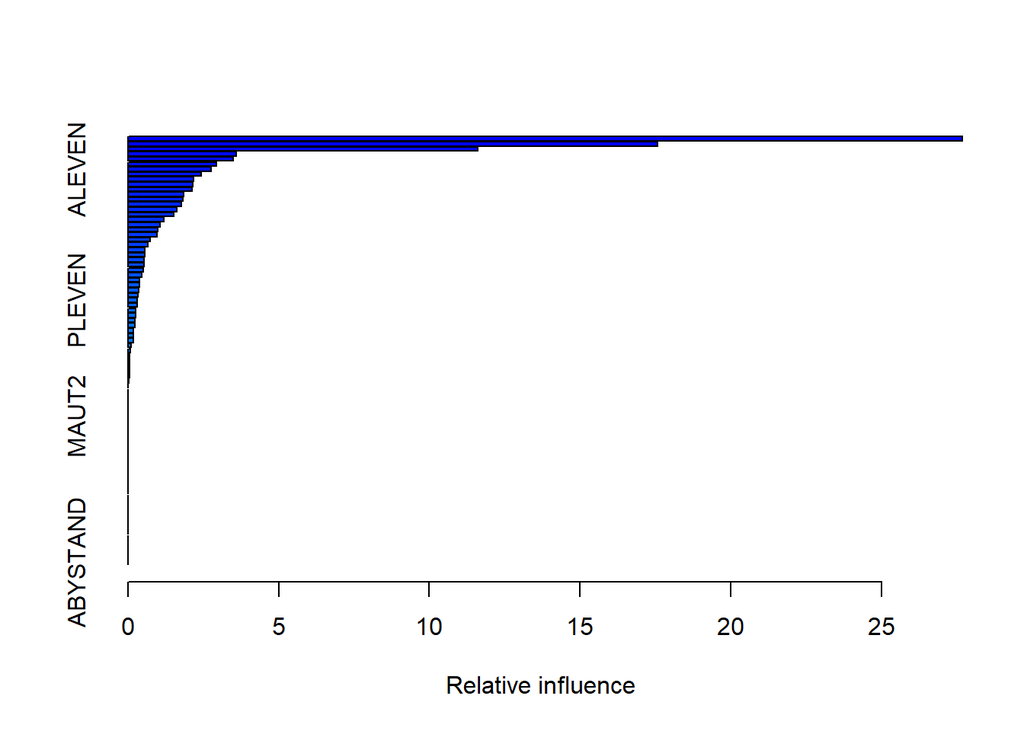

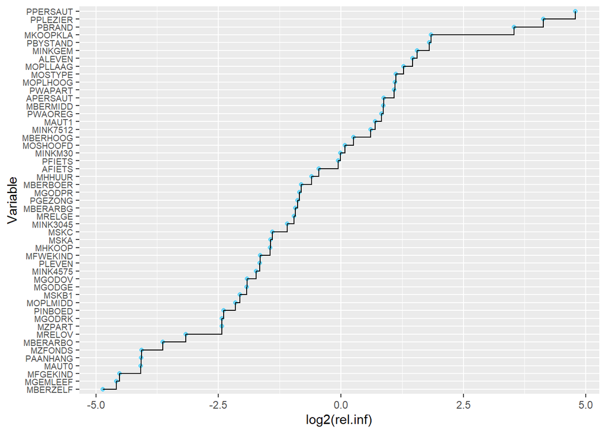

```r
library(gbm)
caravan <- ISLR::Caravan
inds <- sample(nrow(caravan), 1000)
train <- caravan[inds,]
test <- caravan[-inds,]

car_boost <- gbm(data = caravan %>% mutate(Purchase = as.numeric(Purchase) - 1), Purchase ~ ., n.trees = 1000, shrinkage = .01, distribution = "bernoulli" )

summary(car_boost) %>% filter(rel.inf > 0) %>%
  mutate(row = rev(seq(1, nrow(.)))) %>%
  ggplot(aes(x = log2(rel.inf), y = fct_reorder(factor(var), rel.inf))) +
  geom_point(alpha = .5, col = "deepskyblue") +
  geom_step(aes(y=row)) +
  labs(y = "Variable")+
  theme(axis.text.y = element_text(size = 7))
```

The model is decently accurate but neither sensitive nor specific (many false negatives and false positives). It has little use as is, given prior probabilities.

```r
car_pred <- predict(car_boost, newdata = test, type = "response")
```

```
## Using 1000 trees...
```

```r
car_pred <- factor(ifelse(car_pred >=.2, "Yes", "No"))

table(car_pred, actual = test$Purchase)
```

```
##         actual
## car_pred   No  Yes
##      No  4409  236
##      Yes  113   64
```

Still, a binomial model does much worse.

```r
vars <- summary(car_boost) %>% filter(rel.inf > 1) %>% pull(var)
```

[figure not shown]

```r
form <- formula(paste("Purchase ~", paste(vars, collapse = " + ")))

car_glm <- glm(train, formula = form, family = "binomial")
summary(car_glm)
```

```
##
## Call:
## glm(formula = form, family = "binomial", data = train)
##
## Deviance Residuals:
##     Min       1Q   Median       3Q      Max
## -0.9297  -0.3440  -0.2402  -0.1668   2.9459
##
## Coefficients:
##              Estimate Std. Error z value Pr(>|z|)
## (Intercept) -6.731604   1.374478  -4.898  9.7e-07 ***
## PPERSAUT     0.319453   0.117945   2.708  0.00676 **
## PPLEZIER     0.658213   0.252856   2.603  0.00924 **
## PBRAND      -0.009874   0.107285  -0.092  0.92667
## MKOOPKLA     0.063888   0.109514   0.583  0.55964
## PBYSTAND     0.080638   0.276835   0.291  0.77083
## MINKGEM      0.356024   0.177011   2.011  0.04429 *
## ALEVEN       0.110986   0.368275   0.301  0.76314
## MOPLLAAG     0.027698   0.103412   0.268  0.78882
## MOSTYPE      0.111391   0.114439   0.973  0.33037
## MOPLHOOG     0.182983   0.131401   1.393  0.16376
## PWAPART      0.347758   0.201221   1.728  0.08395 .
## APERSAUT    -0.587679   0.547417  -1.074  0.28302
## MBERMIDD     0.101417   0.089339   1.135  0.25630
## PWAOREG      0.284868   0.201702   1.412  0.15786
## MAUT1        0.019177   0.108078   0.177  0.85917
## MINK7512    -0.201030   0.173833  -1.156  0.24750
## MBERHOOG    -0.072826   0.116728  -0.624  0.53270
## MOSHOOFD    -0.413348   0.507323  -0.815  0.41521
## ---
## Signif. codes:  0 '***' 0.001 '**' 0.01 '*' 0.05 '.' 0.1 ' ' 1
##
## (Dispersion parameter for binomial family taken to be 1)
##
##     Null deviance: 385.17  on 999  degrees of freedom
## Residual deviance: 344.47  on 981  degrees of freedom
## AIC: 382.47
##
## Number of Fisher Scoring iterations: 6
```

```r
car_pred2 <- predict(car_glm, test, type = "response") %>%
  as.numeric() %>%
  {factor(ifelse(. >=.2, "Yes", "No"))}

table(car_pred2, actual = test$Purchase)
```

```
##          actual
## car_pred2   No  Yes
##       No  4464  281
##       Yes   58   19
```